# Where do Great Knots stop during migration?

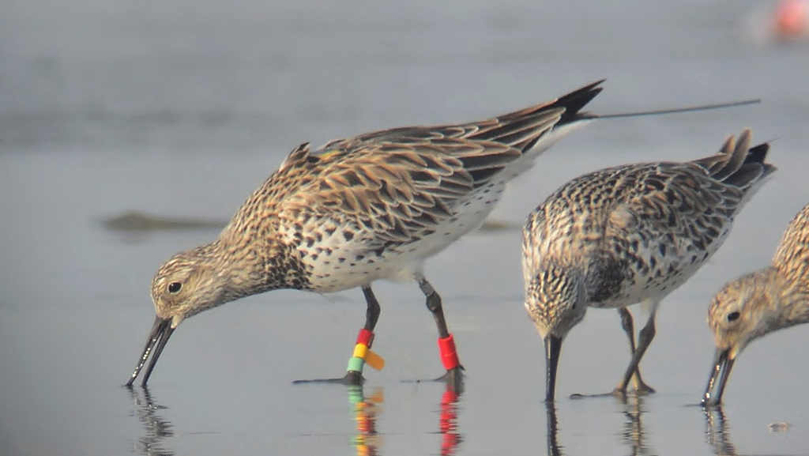

Great Knots (*Calidris tenuirostris*) are small migratory shorebirds in the East Asian-Australasian Flyway that fly each year between breeding grounds in the eastern Russian Arctic and nonbreeding grounds in Australia. They are also [endangered](https://www.iucnredlist.org/species/22693359/155482913). One major threat is the habitat destruction and degradation in their stopping areas during their migration.

In 2015-2017, a team of scientists from the Netherlands (University of Groningen and NIOZ), USA (US Geological Survey) and Australia, brought together by the [Global Flyway Network](https://www.globalflywaynetwork.org/), tracked Great Knots year-round with satellite transmitters. This is the first time that the entire migration journey has been tracked.

Here are the 92 sites where these great knots stopped.

Prior to this study, many of these sites (63%) were not known as important for migratory shorebirds. The study has highlighted regions potentially important for shorebirds but lack ecological information and conservation recognition, such as those in Southern China and Southeast Asia.

Find out more in the [article in the Journal of Applied Ecology.](https://doi.org/10.1111/1365-2664.13474)

[interactive chart not shown]

Size of circle is in proportion to the number of tracked great knots stopping at the site.

Interactive map created by YC Chan.

[Data: Chan et al. (2019) Filling knowledge gaps in a threatened shorebird flyway through satellite tracking. Journal of Applied Ecology.](https://doi.org/10.1111/1365-2664.13474)